fossil

# Random forests in linkage disequilibrium, dug back up.

34 results: 11 exact, 7 agree, 10 partly agree, 1 differs, 5 not attempted. The lost program was rebuilt from the paper and checked against Breiman and Cutler's Fortran, and the simulations were run again.

See every result

## Install rfld

Python package

```
pip install "git+https://github.com/jeonglab-bcm/fossil#subdirectory=PMC2666661/package"
```

Python 3.10 or later, with NumPy and Numba.

[README](https://github.com/jeonglab-bcm/fossil/blob/main/PMC2666661/package/README.md) [Tutorial](https://github.com/jeonglab-bcm/fossil/blob/main/PMC2666661/package/tutorial/TUTORIAL.md)

## Fig. 1

Fig. 1. Mean IM of the risk SNPs (H4M4, K4S4) against the number of SNPs in LD with each risk SNP (r series) or with each of four noise SNPs (n series), for RF0 and RF1 with IM0 and IM1.

Agrees

Published

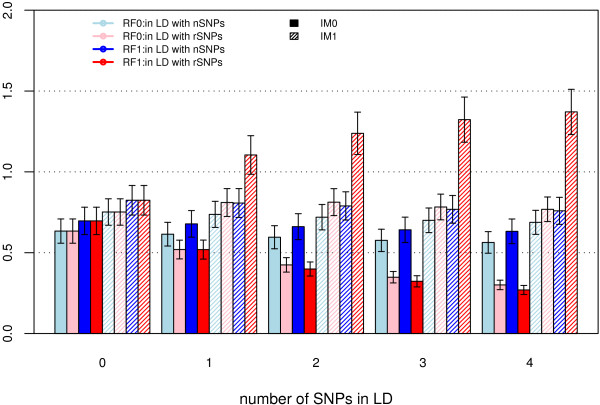

Our run

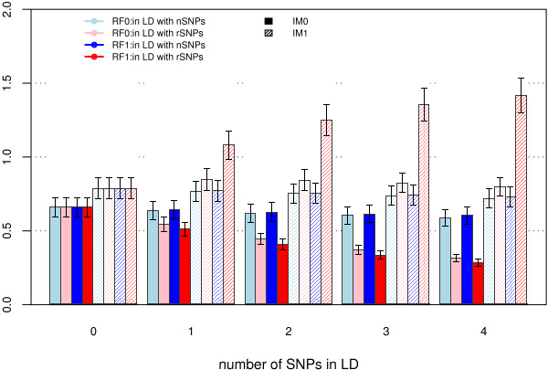

**Fig. 1, mean IM of the risk SNPs (40 bars)**

40 of 40 values, Agrees

## Fig. 2

Fig. 2. Share of replicates where every risk SNP and LD.rSNP has a higher IM than every noise SNP.

Agrees

Published

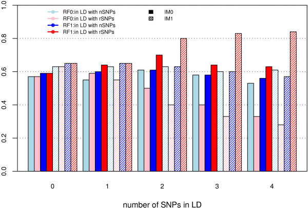

Our run

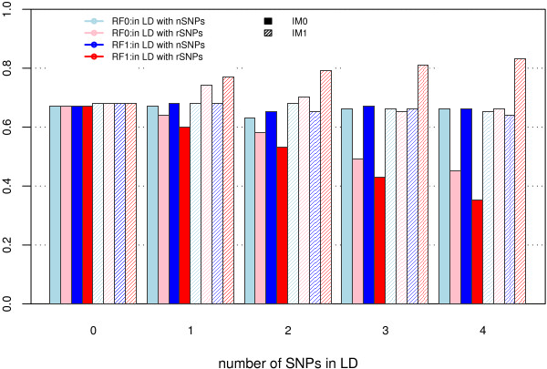

**Fig. 2, share of replicates with all risk SNPs above the noise (40 bars)**

36 of 40 values, Agrees

Fig. 2 has the bars of RF1:IM0 and RF0:IM1 in the r series swapped: exchanged, they come back 10 of 10; as labelled, 6 of 10.

## Fig. 3

Fig. 3. Share of replicates with each risk SNP (or one of its LD.rSNPs) among the top X SNPs: (a) RF0 with IM0 and IM1 by number of LD.rSNPs; (b) 1 and 4 LD.rSNPs; (c) the four RF/IM combinations.

Partly agrees

Published

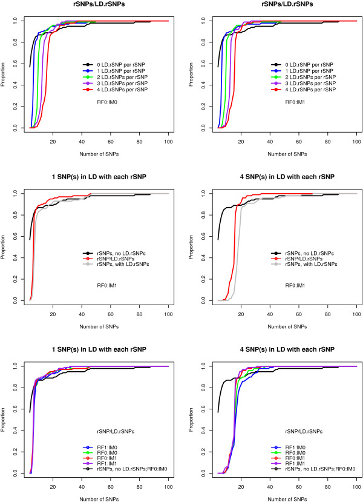

Our run

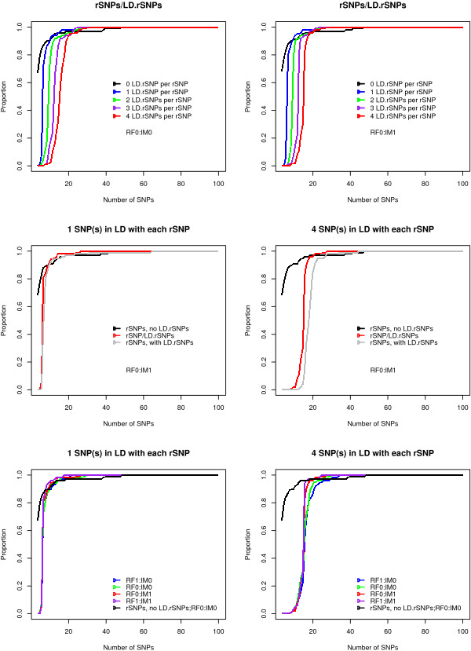

**Fig. 3a, top X curves by LD.rSNPs, RF0:IM0 and RF0:IM1**

49 of 50 values, Partly agrees

**Fig. 3b, rSNPs with and without their LD.rSNPs, 1 and 4 per rSNP**

27 of 27 values, Agrees

**Fig. 3c, the four RF/IM combinations, 1 and 4 LD.rSNPs**

44 of 45 values, Partly agrees

One of 50 points misses: the paper's curve at X = 12 (0.44) is read where ours jumps from 0.23 at X = 12 to 0.81 at X = 13; half a step of X, about one pixel, covers it. One of 45 points misses: RF0:IM1 with 1 LD.rSNP at X = 5 reads 0.13 where our curve goes 0.00, 0.06, 0.80 at X = 5, 6, 7; at X = 5.5 it is 0.03, within tolerance.

## Fig. 4

Fig. 4. Mean IM of the risk SNPs, true risk haplotypes and predicted risk haplotypes (H4M4, K4S4N100) against r² between the two SNPs of a risk haplotype.

Partly agrees

Published

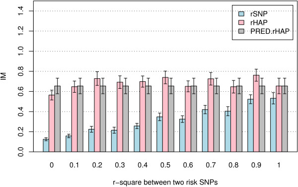

Our run

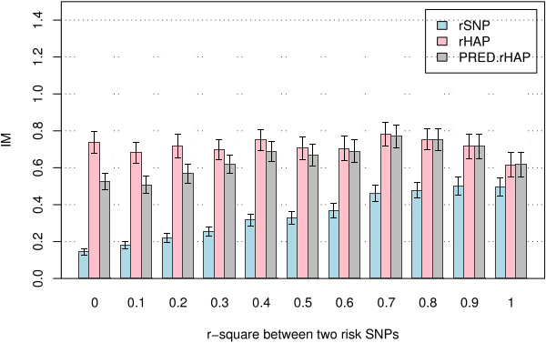

**Fig. 4, mean IM of risk SNPs, true and predicted risk haplotypes (33 bars)**

30 of 33 values, Partly agrees

30 of 33 bars agree. The paper's PRED.rHAP bars are all the same height (0.654, error bars too): two of them miss ours at r2 = 0 and 0.1, a plotting slip. The rHAP bar at r2 = 0 (0.565 against our 0.736) is the low-r2 gap of Fig. 5.

## Fig. 5

Fig. 5. Share of replicates where every risk SNP, risk haplotype or predicted haplotype has a higher IM than every noise SNP.

Partly agrees

Published

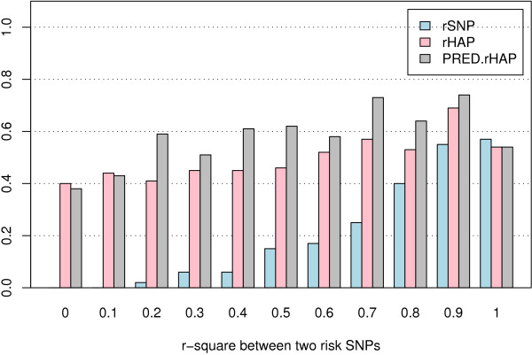

Our run

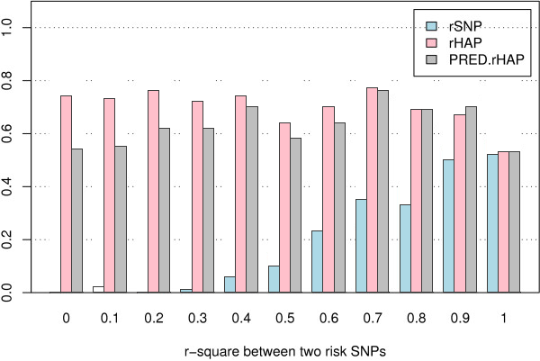

**Fig. 5, share of replicates with all risk variables above the noise (33 bars)**

28 of 33 values, Partly agrees

At r2 0-0.4 the paper's true haplotypes beat every noise SNP in 40-45% of replicates, ours in 72-76%; from r2 = 0.5 on they agree. Our risk haplotypes carry the same risk at every r2, as the model says, so ours stay flat.

## Fig. 6

Fig. 6. Share of replicates with all risk variables among the top X: (a) SNPs, both and the best SNP of each haplotype; (b) true and predicted haplotypes; (c) the four codings at r² = 0 and 0.9.

Partly agrees

Published

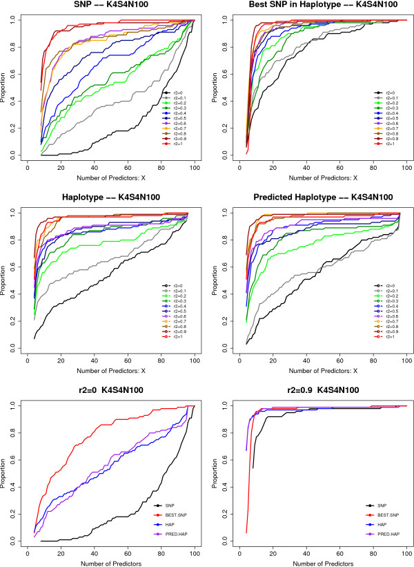

Our run

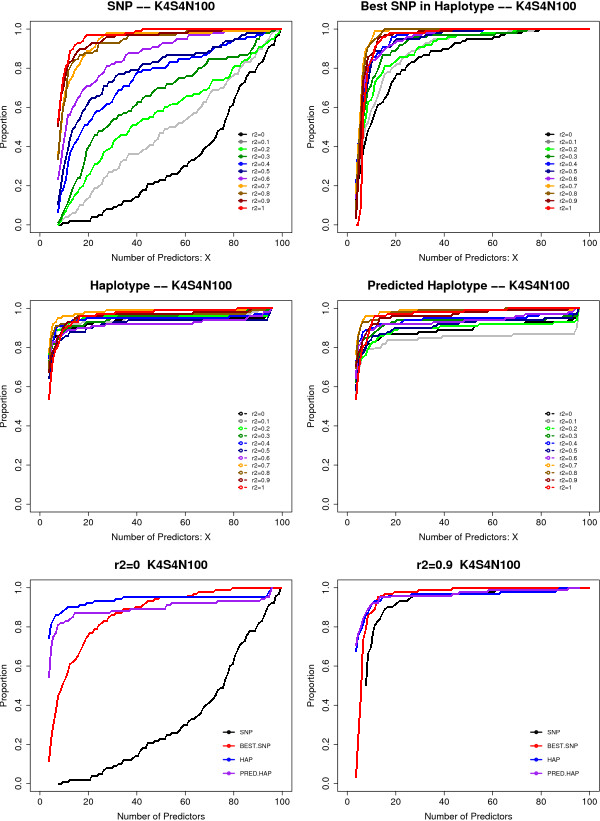

**Fig. 6a, top X curves of the risk SNPs (both, and the best of each pair)**

25 of 26 values, Partly agrees

**Fig. 6b, top X curves of true and predicted haplotypes**

14 of 27 values, Partly agrees

**Fig. 6c, the four codings at r2 = 0 and 0.9**

8 of 18 values, Partly agrees

One of 26 points misses: at X = 5 the best-SNP curve for r2 = 1 reads 0.12, but with r2 = 1 the two SNPs are copies and ours is 0; our r2 = 0.9 curve (dark red, next to red in the 87 dpi figure) is 0.21 there. The paper's true and predicted haplotype curves are low at small r2; ours are high at every r2. At r2 = 0 the published curve also contradicts the paper's own Fig. 5: 40% of replicates have all four risk haplotypes above every noise SNP, so at least 40% have them in the top 5, but the curve reads 12%. At r2 = 0 the paper's HAP and PRED.HAP curves are low and ours high (the low-r2 gap of Figs 5 and 6b); the SNP and best-SNP curves agree except one best-SNP point. At r2 = 0.9 all four codings agree.

## Every result

Every figure, table and claim of the paper. A figure value agrees when it is within 3 combined Monte Carlo standard errors and one pixel of the published one.

Result

Verdict

Measure

Why

Table 1, K, GRRs and lambda_s of the seven genetic models

Exact

- H1M1 number of risk SNPs: paper 1, ours **1**
- H1M1 GRR het: paper ∞, ours **∞**
- H1M1 GRR hom: paper ∞, ours **∞**
- H1M1 K: paper 0.05, ours **0.05319**
- H1M1 lambda_s: paper 9, ours **8.900**
- H2M3 number of risk SNPs: paper 6, ours **6**
- H2M3 GRR het: paper 5.22, ours **5.22662**
- H2M3 GRR hom: paper 5.22, ours **5.22662**
- H2M3 K: paper 0.02, ours **0.01868**
- H2M3 lambda_s: paper 9, ours **9.005**
- H3M3 number of risk SNPs: paper 9, ours **9**
- H3M3 GRR het: paper 3.47, ours **3.46847**
- H3M3 GRR hom: paper 3.47, ours **3.46847**
- H3M3 K: paper 0.02, ours **0.01759**
- H3M3 lambda_s: paper 9, ours **9.004**
- H3M4 number of risk SNPs: paper 12, ours **12**
- H3M4 GRR het: paper 2.54, ours **2.54126**
- H3M4 GRR hom: paper 2.54, ours **2.54126**
- H3M4 K: paper 0.02, ours **0.02076**
- H3M4 lambda_s: paper 6, ours **6.003**
- H9M2 number of risk SNPs: paper 18, ours **18**
- H9M2 GRR het: paper 3.02, ours **3.02016**
- H9M2 GRR hom: paper 3.02, ours **3.02016**
- H9M2 K: paper 0.03, ours **0.02684**
- H9M2 lambda_s: paper 9, ours **8.992**
- H4M4 number of risk SNPs: paper 16, ours **16**
- H4M4 GRR het: paper 1.63, ours **1.62599**
- H4M4 GRR hom: paper 1.79, ours **1.79239**
- H4M4 K: paper 0.10, ours **0.09800**
- H4M4 lambda_s: paper 2, ours **2.006**
- H8M4 number of risk SNPs: paper 32, ours **32**
- H8M4 GRR het: paper 1.34, ours **1.34468**
- H8M4 GRR hom: paper 1.4, ours **1.4010**
- H8M4 K: paper 0.10, ours **0.09846**
- H8M4 lambda_s: paper 2, ours **2.001**

Table 5, the 13 LD models

Not attempted

A design table: it defines the LD models the simulation uses (rfld.LD_MODELS).

Fig. 1, mean IM of the risk SNPs (40 bars)

Agrees

40 of 40 values

- LD 0: RF0:IM0 n: paper 0.636, ours **0.658**
- LD 0: RF0:IM0 r: paper 0.636, ours **0.658**
- LD 0: RF1:IM0 n: paper 0.699, ours **0.658**
- LD 0: RF1:IM0 r: paper 0.699, ours **0.658**
- LD 0: RF0:IM1 n: paper 0.754, ours **0.784**
- LD 0: RF0:IM1 r: paper 0.754, ours **0.784**
- LD 0: RF1:IM1 n: paper 0.822, ours **0.784**
- LD 0: RF1:IM1 r: paper 0.822, ours **0.784**
- LD 1: RF0:IM0 n: paper 0.612, ours **0.633**
- LD 1: RF0:IM0 r: paper 0.519, ours **0.540**
- LD 1: RF1:IM0 n: paper 0.680, ours **0.639**
- LD 1: RF1:IM0 r: paper 0.519, ours **0.508**
- LD 1: RF0:IM1 n: paper 0.736, ours **0.763**
- LD 1: RF0:IM1 r: paper 0.810, ours **0.845**
- LD 1: RF1:IM1 n: paper 0.810, ours **0.767**
- LD 1: RF1:IM1 r: paper 1.107, ours **1.077**
- LD 2: RF0:IM0 n: paper 0.593, ours **0.616**
- LD 2: RF0:IM0 r: paper 0.426, ours **0.438**
- LD 2: RF1:IM0 n: paper 0.661, ours **0.624**
- LD 2: RF1:IM0 r: paper 0.401, ours **0.404**
- LD 2: RF0:IM1 n: paper 0.717, ours **0.749**
- LD 2: RF0:IM1 r: paper 0.810, ours **0.840**
- LD 2: RF1:IM1 n: paper 0.791, ours **0.752**
- LD 2: RF1:IM1 r: paper 1.237, ours **1.247**
- LD 3: RF0:IM0 n: paper 0.575, ours **0.601**
- LD 3: RF0:IM0 r: paper 0.345, ours **0.366**
- LD 3: RF1:IM0 n: paper 0.643, ours **0.611**
- LD 3: RF1:IM0 r: paper 0.321, ours **0.332**
- LD 3: RF0:IM1 n: paper 0.699, ours **0.734**
- LD 3: RF0:IM1 r: paper 0.785, ours **0.822**
- LD 3: RF1:IM1 n: paper 0.767, ours **0.737**
- LD 3: RF1:IM1 r: paper 1.324, ours **1.352**
- LD 4: RF0:IM0 n: paper 0.562, ours **0.583**
- LD 4: RF0:IM0 r: paper 0.302, ours **0.311**
- LD 4: RF1:IM0 n: paper 0.630, ours **0.600**
- LD 4: RF1:IM0 r: paper 0.271, ours **0.279**
- LD 4: RF0:IM1 n: paper 0.686, ours **0.716**
- LD 4: RF0:IM1 r: paper 0.767, ours **0.795**
- LD 4: RF1:IM1 n: paper 0.760, ours **0.726**
- LD 4: RF1:IM1 r: paper 1.373, ours **1.416**

Fig. 2, share of replicates with all risk SNPs above the noise (40 bars)

Agrees

36 of 40 values

- LD 0: RF0:IM0 n: paper 0.569, ours **0.670**
- LD 0: RF0:IM0 r: paper 0.569, ours **0.670**
- LD 0: RF1:IM0 n: paper 0.591, ours **0.670**
- LD 0: RF1:IM0 r: paper 0.591, ours **0.670**
- LD 0: RF0:IM1 n: paper 0.631, ours **0.680**
- LD 0: RF0:IM1 r: paper 0.631, ours **0.680**
- LD 0: RF1:IM1 n: paper 0.650, ours **0.680**
- LD 0: RF1:IM1 r: paper 0.650, ours **0.680**
- LD 1: RF0:IM0 n: paper 0.551, ours **0.670**
- LD 1: RF0:IM0 r: paper 0.591, ours **0.640**
- LD 1: RF1:IM0 n: paper 0.600, ours **0.680**
- LD 1: RF1:IM0 r: paper 0.640, ours **0.600**
- LD 1: RF0:IM1 n: paper 0.631, ours **0.680**
- LD 1: RF0:IM1 r: paper 0.551, ours **0.740**
- LD 1: RF1:IM1 n: paper 0.650, ours **0.680**
- LD 1: RF1:IM1 r: paper 0.650, ours **0.770**
- LD 2: RF0:IM0 n: paper 0.610, ours **0.630**
- LD 2: RF0:IM0 r: paper 0.501, ours **0.580**
- LD 2: RF1:IM0 n: paper 0.610, ours **0.650**
- LD 2: RF1:IM0 r: paper 0.702, ours **0.530**
- LD 2: RF0:IM1 n: paper 0.631, ours **0.680**
- LD 2: RF0:IM1 r: paper 0.399, ours **0.700**
- LD 2: RF1:IM1 n: paper 0.631, ours **0.650**
- LD 2: RF1:IM1 r: paper 0.801, ours **0.790**
- LD 3: RF0:IM0 n: paper 0.582, ours **0.660**
- LD 3: RF0:IM0 r: paper 0.399, ours **0.490**
- LD 3: RF1:IM0 n: paper 0.582, ours **0.670**
- LD 3: RF1:IM0 r: paper 0.640, ours **0.430**
- LD 3: RF0:IM1 n: paper 0.600, ours **0.660**
- LD 3: RF0:IM1 r: paper 0.331, ours **0.650**
- LD 3: RF1:IM1 n: paper 0.600, ours **0.660**
- LD 3: RF1:IM1 r: paper 0.829, ours **0.810**
- LD 4: RF0:IM0 n: paper 0.529, ours **0.660**
- LD 4: RF0:IM0 r: paper 0.331, ours **0.450**
- LD 4: RF1:IM0 n: paper 0.560, ours **0.660**
- LD 4: RF1:IM0 r: paper 0.631, ours **0.350**
- LD 4: RF0:IM1 n: paper 0.610, ours **0.650**
- LD 4: RF0:IM1 r: paper 0.282, ours **0.660**
- LD 4: RF1:IM1 n: paper 0.569, ours **0.640**
- LD 4: RF1:IM1 r: paper 0.842, ours **0.830**

Fig. 2 has the bars of RF1:IM0 and RF0:IM1 in the r series swapped: exchanged, they come back 10 of 10; as labelled, 6 of 10.

Fig. 3a, top X curves by LD.rSNPs, RF0:IM0 and RF0:IM1

Partly agrees

49 of 50 values

- a.left n0, X=5: paper 0.677, ours **0.800**
- a.left n0, X=8: paper 0.842, ours **0.890**
- a.left n0, X=25: paper 0.929, ours **0.970**
- a.left n0, X=30: paper 0.947, ours **0.970**
- a.left r1, X=5: paper 0.057, ours **0.010**
- a.left r1, X=8: paper 0.785, ours **0.820**
- a.left r1, X=10: paper 0.870, ours **0.890**
- a.left r1, X=12: paper 0.895, ours **0.940**
- a.left r2, X=8: paper 0.086, ours **0.120**
- a.left r2, X=10: paper 0.556, ours **0.700**
- a.left r2, X=12: paper 0.859, ours **0.880**
- a.left r2, X=15: paper 0.904, ours **0.930**
- a.left r2, X=20: paper 0.958, ours **0.960**
- a.left r3, X=8: paper 0.029, ours **0.010**
- a.left r3, X=10: paper 0.103, ours **0.140**
- a.left r3, X=12: paper 0.383, ours **0.240**
- a.left r3, X=15: paper 0.842, ours **0.860**
- a.left r3, X=20: paper 0.915, ours **0.940**
- a.left r3, X=25: paper 0.975, ours **1.000**
- a.left r4, X=8: paper 0.006, ours **0.010**
- a.left r4, X=10: paper 0.037, ours **0.020**
- a.left r4, X=12: paper 0.134, ours **0.100**
- a.left r4, X=15: paper 0.392, ours **0.310**
- a.left r4, X=20: paper 0.893, ours **0.920**
- a.left r4, X=25: paper 0.952, ours **0.960**
- a.right n0, X=5: paper 0.669, ours **0.780**
- a.right n0, X=10: paper 0.867, ours **0.910**
- a.right n0, X=20: paper 0.890, ours **0.970**
- a.right n0, X=25: paper 0.929, ours **0.970**
- a.right n0, X=30: paper 0.947, ours **0.970**
- a.right r1, X=5: paper 0.071, ours **0.000**
- a.right r1, X=8: paper 0.828, ours **0.840**
- a.right r1, X=10: paper 0.881, ours **0.920**
- a.right r1, X=12: paper 0.895, ours **0.950**
- a.right r1, X=15: paper 0.915, ours **0.980**
- a.right r2, X=8: paper 0.128, ours **0.070**
- a.right r2, X=10: paper 0.632, ours **0.780**
- a.right r2, X=12: paper 0.876, ours **0.920**
- a.right r2, X=15: paper 0.924, ours **0.940**
- a.right r3, X=8: paper 0.018, ours **0.010**
- a.right r3, X=10: paper 0.103, ours **0.070**
- a.right r3, X=12: paper 0.440, ours **0.230**
- a.right r3, X=15: paper 0.893, ours **0.930**
- a.right r3, X=20: paper 0.952, ours **0.980**
- a.right r4, X=8: paper 0.006, ours **0.000**
- a.right r4, X=10: paper 0.037, ours **0.020**
- a.right r4, X=12: paper 0.148, ours **0.080**
- a.right r4, X=15: paper 0.457, ours **0.300**
- a.right r4, X=20: paper 0.927, ours **0.960**
- a.right r4, X=25: paper 0.980, ours **0.990**

One of 50 points misses: the paper's curve at X = 12 (0.44) is read where ours jumps from 0.23 at X = 12 to 0.81 at X = 13; half a step of X, about one pixel, covers it.

Fig. 3b, rSNPs with and without their LD.rSNPs, 1 and 4 per rSNP

Agrees

27 of 27 values

- b.left n0 rSNPs, X=5: paper 0.679, ours **0.780**
- b.left n0 rSNPs, X=10: paper 0.869, ours **0.910**
- b.left n0 rSNPs, X=15: paper 0.886, ours **0.950**
- b.left n0 rSNPs, X=20: paper 0.892, ours **0.970**
- b.left n0 rSNPs, X=30: paper 0.948, ours **0.970**
- b.left r1 rSNP/LD.rSNPs, X=5: paper 0.093, ours **0.000**
- b.left r1 rSNP/LD.rSNPs, X=8: paper 0.829, ours **0.840**
- b.left r1 rSNP/LD.rSNPs, X=10: paper 0.883, ours **0.920**
- b.left r1 rSNP/LD.rSNPs, X=12: paper 0.897, ours **0.950**
- b.left r1 rSNP/LD.rSNPs, X=15: paper 0.917, ours **0.980**
- b.left r1 rSNP/LD.rSNPs, X=20: paper 0.954, ours **0.980**
- b.left r1 rSNPs, X=5: paper 0.025, ours **0.000**
- b.left r1 rSNPs, X=8: paper 0.606, ours **0.800**
- b.left r1 rSNPs, X=10: paper 0.824, ours **0.910**
- b.left r1 rSNPs, X=12: paper 0.846, ours **0.940**
- b.left r1 rSNPs, X=20: paper 0.923, ours **0.970**
- b.left r1 rSNPs, X=25: paper 0.928, ours **0.980**
- b.right n0 rSNPs, X=5: paper 0.671, ours **0.780**
- b.right n0 rSNPs, X=8: paper 0.841, ours **0.890**
- b.right n0 rSNPs, X=10: paper 0.869, ours **0.910**
- b.right n0 rSNPs, X=15: paper 0.886, ours **0.950**
- b.right n0 rSNPs, X=20: paper 0.892, ours **0.970**
- b.right n0 rSNPs, X=30: paper 0.948, ours **0.970**
- b.right r4 rSNP/LD.rSNPs, X=10: paper 0.039, ours **0.020**
- b.right r4 rSNP/LD.rSNPs, X=12: paper 0.150, ours **0.080**
- b.right r4 rSNP/LD.rSNPs, X=15: paper 0.456, ours **0.300**
- b.right r4 rSNP/LD.rSNPs, X=20: paper 0.928, ours **0.960**

Fig. 3c, the four RF/IM combinations, 1 and 4 LD.rSNPs

Partly agrees

44 of 45 values

- c.left RF1:IM0, X=5: paper 0.003, ours **0.000**
- c.left RF1:IM0, X=8: paper 0.736, ours **0.820**
- c.left RF1:IM0, X=10: paper 0.866, ours **0.900**
- c.left RF1:IM0, X=12: paper 0.880, ours **0.920**
- c.left RF1:IM0, X=25: paper 0.960, ours **1.000**
- c.left RF0:IM1, X=5: paper 0.127, ours **0.000**
- c.left RF0:IM1, X=8: paper 0.841, ours **0.840**
- c.left RF0:IM1, X=20: paper 0.954, ours **0.980**
- c.left RF1:IM1, X=5: paper 0.045, ours **0.000**
- c.left RF1:IM1, X=8: paper 0.852, ours **0.890**
- c.left RF1:IM1, X=10: paper 0.886, ours **0.950**
- c.left RF1:IM1, X=12: paper 0.897, ours **0.960**
- c.left RF1:IM1, X=15: paper 0.917, ours **0.980**
- c.left RF1:IM1, X=20: paper 0.937, ours **1.000**
- c.left RF1:IM1, X=30: paper 0.988, ours **1.000**
- c.left RF1:IM1, X=40: paper 0.999, ours **1.000**
- c.left n0 RF0:IM0, X=5: paper 0.674, ours **0.800**
- c.left n0 RF0:IM0, X=15: paper 0.886, ours **0.960**
- c.left n0 RF0:IM0, X=20: paper 0.892, ours **0.970**
- c.left n0 RF0:IM0, X=25: paper 0.926, ours **0.970**
- c.left n0 RF0:IM0, X=30: paper 0.948, ours **0.970**
- c.right RF1:IM0, X=15: paper 0.286, ours **0.230**
- c.right RF1:IM0, X=20: paper 0.827, ours **0.850**
- c.right RF1:IM0, X=25: paper 0.889, ours **0.950**
- c.right RF1:IM0, X=30: paper 0.937, ours **0.970**
- c.right RF1:IM0, X=40: paper 0.988, ours **1.000**
- c.right RF0:IM0, X=20: paper 0.889, ours **0.920**
- c.right RF0:IM0, X=25: paper 0.951, ours **0.960**
- c.right RF0:IM1, X=10: paper 0.034, ours **0.020**
- c.right RF0:IM1, X=12: paper 0.172, ours **0.080**
- c.right RF0:IM1, X=20: paper 0.926, ours **0.960**
- c.right RF1:IM1, X=8: paper 0.020, ours **0.010**
- c.right RF1:IM1, X=10: paper 0.056, ours **0.030**
- c.right RF1:IM1, X=12: paper 0.127, ours **0.060**
- c.right RF1:IM1, X=15: paper 0.490, ours **0.300**
- c.right RF1:IM1, X=20: paper 0.957, ours **0.970**
- c.right RF1:IM1, X=25: paper 0.988, ours **1.000**
- c.right RF1:IM1, X=30: paper 0.994, ours **1.000**
- c.right RF1:IM1, X=40: paper 0.999, ours **1.000**
- c.right n0 RF0:IM0, X=5: paper 0.671, ours **0.800**
- c.right n0 RF0:IM0, X=8: paper 0.841, ours **0.890**
- c.right n0 RF0:IM0, X=10: paper 0.869, ours **0.900**
- c.right n0 RF0:IM0, X=15: paper 0.886, ours **0.960**
- c.right n0 RF0:IM0, X=25: paper 0.926, ours **0.970**
- c.right n0 RF0:IM0, X=30: paper 0.948, ours **0.970**

One of 45 points misses: RF0:IM1 with 1 LD.rSNP at X = 5 reads 0.13 where our curve goes 0.00, 0.06, 0.80 at X = 5, 6, 7; at X = 5.5 it is 0.03, within tolerance.

Fig. 4, mean IM of risk SNPs, true and predicted risk haplotypes (33 bars)

Partly agrees

30 of 33 values

- r2 0.0: rSNP: paper 0.126, ours **0.143**
- r2 0.0: rHAP: paper 0.565, ours **0.736**
- r2 0.0: PRED.rHAP: paper 0.653, ours **0.523**
- r2 0.1: rSNP: paper 0.161, ours **0.179**
- r2 0.1: rHAP: paper 0.649, ours **0.679**
- r2 0.1: PRED.rHAP: paper 0.653, ours **0.505**
- r2 0.2: rSNP: paper 0.225, ours **0.217**
- r2 0.2: rHAP: paper 0.727, ours **0.715**
- r2 0.2: PRED.rHAP: paper 0.653, ours **0.566**
- r2 0.3: rSNP: paper 0.215, ours **0.253**
- r2 0.3: rHAP: paper 0.693, ours **0.694**
- r2 0.3: PRED.rHAP: paper 0.653, ours **0.615**
- r2 0.4: rSNP: paper 0.259, ours **0.314**
- r2 0.4: rHAP: paper 0.698, ours **0.748**
- r2 0.4: PRED.rHAP: paper 0.653, ours **0.686**
- r2 0.5: rSNP: paper 0.348, ours **0.326**
- r2 0.5: rHAP: paper 0.742, ours **0.704**
- r2 0.5: PRED.rHAP: paper 0.653, ours **0.667**
- r2 0.6: rSNP: paper 0.328, ours **0.366**
- r2 0.6: rHAP: paper 0.653, ours **0.702**
- r2 0.6: PRED.rHAP: paper 0.653, ours **0.687**
- r2 0.7: rSNP: paper 0.422, ours **0.458**
- r2 0.7: rHAP: paper 0.727, ours **0.779**
- r2 0.7: PRED.rHAP: paper 0.653, ours **0.767**
- r2 0.8: rSNP: paper 0.407, ours **0.476**
- r2 0.8: rHAP: paper 0.649, ours **0.751**
- r2 0.8: PRED.rHAP: paper 0.653, ours **0.749**
- r2 0.9: rSNP: paper 0.525, ours **0.498**
- r2 0.9: rHAP: paper 0.762, ours **0.714**
- r2 0.9: PRED.rHAP: paper 0.653, ours **0.713**
- r2 1.0: rSNP: paper 0.535, ours **0.495**
- r2 1.0: rHAP: paper 0.653, ours **0.613**
- r2 1.0: PRED.rHAP: paper 0.653, ours **0.614**

30 of 33 bars agree. The paper's PRED.rHAP bars are all the same height (0.654, error bars too): two of them miss ours at r2 = 0 and 0.1, a plotting slip. The rHAP bar at r2 = 0 (0.565 against our 0.736) is the low-r2 gap of Fig. 5.

Fig. 5, share of replicates with all risk variables above the noise (33 bars)

Partly agrees

28 of 33 values

- r2 0.0: rSNP: paper -0.000, ours **0.000**
- r2 0.0: rHAP: paper 0.400, ours **0.740**
- r2 0.0: PRED.rHAP: paper 0.379, ours **0.540**
- r2 0.1: rSNP: paper -0.000, ours **0.020**
- r2 0.1: rHAP: paper 0.440, ours **0.730**
- r2 0.1: PRED.rHAP: paper 0.430, ours **0.550**
- r2 0.2: rSNP: paper 0.019, ours **0.000**
- r2 0.2: rHAP: paper 0.410, ours **0.760**
- r2 0.2: PRED.rHAP: paper 0.590, ours **0.620**
- r2 0.3: rSNP: paper 0.060, ours **0.010**
- r2 0.3: rHAP: paper 0.451, ours **0.720**
- r2 0.3: PRED.rHAP: paper 0.512, ours **0.620**
- r2 0.4: rSNP: paper 0.060, ours **0.060**
- r2 0.4: rHAP: paper 0.451, ours **0.740**
- r2 0.4: PRED.rHAP: paper 0.610, ours **0.700**
- r2 0.5: rSNP: paper 0.152, ours **0.100**
- r2 0.5: rHAP: paper 0.461, ours **0.640**
- r2 0.5: PRED.rHAP: paper 0.620, ours **0.580**
- r2 0.6: rSNP: paper 0.172, ours **0.230**
- r2 0.6: rHAP: paper 0.522, ours **0.700**
- r2 0.6: PRED.rHAP: paper 0.580, ours **0.640**
- r2 0.7: rSNP: paper 0.250, ours **0.350**
- r2 0.7: rHAP: paper 0.569, ours **0.770**
- r2 0.7: PRED.rHAP: paper 0.729, ours **0.760**
- r2 0.8: rSNP: paper 0.400, ours **0.330**
- r2 0.8: rHAP: paper 0.532, ours **0.690**
- r2 0.8: PRED.rHAP: paper 0.641, ours **0.690**
- r2 0.9: rSNP: paper 0.549, ours **0.500**
- r2 0.9: rHAP: paper 0.692, ours **0.670**
- r2 0.9: PRED.rHAP: paper 0.739, ours **0.700**
- r2 1.0: rSNP: paper 0.569, ours **0.520**
- r2 1.0: rHAP: paper 0.542, ours **0.530**
- r2 1.0: PRED.rHAP: paper 0.542, ours **0.530**

At r2 0-0.4 the paper's true haplotypes beat every noise SNP in 40-45% of replicates, ours in 72-76%; from r2 = 0.5 on they agree. Our risk haplotypes carry the same risk at every r2, as the model says, so ours stay flat.

Fig. 6a, top X curves of the risk SNPs (both, and the best of each pair)

Partly agrees

25 of 26 values

- a.left r2=0.0, X=40: paper 0.091, ours **0.140**
- a.left r2=0.0, X=60: paper 0.183, ours **0.300**
- a.left r2=0.0, X=80: paper 0.444, ours **0.610**
- a.left r2=0.2, X=10: paper 0.061, ours **0.050**
- a.left r2=0.2, X=20: paper 0.273, ours **0.250**
- a.left r2=0.2, X=60: paper 0.587, ours **0.650**
- a.left r2=0.4, X=10: paper 0.193, ours **0.180**
- a.left r2=0.4, X=20: paper 0.390, ours **0.510**
- a.left r2=0.4, X=30: paper 0.515, ours **0.630**
- a.left r2=0.4, X=40: paper 0.656, ours **0.770**
- a.left r2=0.7, X=10: paper 0.416, ours **0.600**
- a.left r2=0.7, X=20: paper 0.722, ours **0.890**
- a.left r2=1.0, X=10: paper 0.702, ours **0.740**
- a.left r2=1.0, X=20: paper 0.921, ours **0.970**
- a.right r2=0.0, X=5: paper 0.130, ours **0.220**
- a.right r2=0.0, X=10: paper 0.342, ours **0.510**
- a.right r2=0.0, X=30: paper 0.715, ours **0.860**
- a.right r2=0.0, X=40: paper 0.817, ours **0.900**
- a.right r2=0.2, X=10: paper 0.630, ours **0.640**
- a.right r2=0.4, X=10: paper 0.671, ours **0.820**
- a.right r2=0.4, X=30: paper 0.932, ours **0.980**
- a.right r2=0.7, X=5: paper 0.329, ours **0.370**
- a.right r2=0.7, X=10: paper 0.873, ours **0.940**
- a.right r2=1.0, X=5: paper 0.122, ours **0.000**
- a.right r2=1.0, X=10: paper 0.891, ours **0.830**
- a.right r2=1.0, X=30: paper 0.996, ours **0.980**

One of 26 points misses: at X = 5 the best-SNP curve for r2 = 1 reads 0.12, but with r2 = 1 the two SNPs are copies and ours is 0; our r2 = 0.9 curve (dark red, next to red in the 87 dpi figure) is 0.21 there.

Fig. 6b, top X curves of true and predicted haplotypes

Partly agrees

14 of 27 values

- b.left r2=0.0, X=5: paper 0.119, ours **0.810**
- b.left r2=0.0, X=30: paper 0.395, ours **0.930**
- b.left r2=0.0, X=40: paper 0.466, ours **0.950**
- b.left r2=0.0, X=80: paper 0.767, ours **0.950**
- b.left r2=0.2, X=5: paper 0.397, ours **0.840**
- b.left r2=0.2, X=10: paper 0.566, ours **0.900**
- b.left r2=0.2, X=20: paper 0.693, ours **0.960**
- b.left r2=0.2, X=30: paper 0.749, ours **0.960**
- b.left r2=0.4, X=5: paper 0.581, ours **0.820**
- b.left r2=0.4, X=10: paper 0.757, ours **0.910**
- b.left r2=0.4, X=80: paper 0.930, ours **0.960**
- b.left r2=0.7, X=5: paper 0.701, ours **0.870**
- b.left r2=0.7, X=10: paper 0.869, ours **0.960**
- b.left r2=1.0, X=5: paper 0.632, ours **0.650**
- b.left r2=1.0, X=10: paper 0.889, ours **0.890**
- b.left r2=1.0, X=20: paper 0.963, ours **0.960**
- b.left r2=1.0, X=80: paper 0.981, ours **0.990**
- b.right r2=0.0, X=5: paper 0.045, ours **0.680**
- b.right r2=0.0, X=10: paper 0.162, ours **0.820**
- b.right r2=0.0, X=80: paper 0.818, ours **0.930**
- b.right r2=0.4, X=5: paper 0.387, ours **0.830**
- b.right r2=0.4, X=10: paper 0.721, ours **0.900**
- b.right r2=0.4, X=20: paper 0.854, ours **0.920**
- b.right r2=0.7, X=5: paper 0.759, ours **0.860**
- b.right r2=0.7, X=10: paper 0.928, ours **0.960**
- b.right r2=1.0, X=5: paper 0.609, ours **0.650**
- b.right r2=1.0, X=10: paper 0.884, ours **0.910**

The paper's true and predicted haplotype curves are low at small r2; ours are high at every r2. At r2 = 0 the published curve also contradicts the paper's own Fig. 5: 40% of replicates have all four risk haplotypes above every noise SNP, so at least 40% have them in the top 5, but the curve reads 12%.

Fig. 6c, the four codings at r2 = 0 and 0.9

Partly agrees

8 of 18 values

- c.left BEST.SNP, X=5: paper 0.141, ours **0.220**
- c.left BEST.SNP, X=10: paper 0.343, ours **0.510**
- c.left BEST.SNP, X=20: paper 0.534, ours **0.750**
- c.left BEST.SNP, X=30: paper 0.713, ours **0.860**
- c.left HAP, X=5: paper 0.100, ours **0.810**
- c.left HAP, X=10: paper 0.218, ours **0.880**
- c.left HAP, X=40: paper 0.468, ours **0.950**
- c.left HAP, X=50: paper 0.559, ours **0.950**
- c.left PRED.HAP, X=5: paper 0.054, ours **0.680**
- c.left PRED.HAP, X=10: paper 0.157, ours **0.820**
- c.left PRED.HAP, X=20: paper 0.287, ours **0.870**
- c.left PRED.HAP, X=30: paper 0.396, ours **0.880**
- c.left PRED.HAP, X=50: paper 0.618, ours **0.890**
- c.right SNP, X=10: paper 0.769, ours **0.690**
- c.right BEST.SNP, X=5: paper 0.371, ours **0.210**
- c.right PRED.HAP, X=5: paper 0.840, ours **0.760**
- c.right PRED.HAP, X=10: paper 0.945, ours **0.910**
- c.right PRED.HAP, X=20: paper 0.988, ours **0.960**

At r2 = 0 the paper's HAP and PRED.HAP curves are low and ours high (the low-r2 gap of Figs 5 and 6b); the SNP and best-SNP curves agree except one best-SNP point. At r2 = 0.9 all four codings agree.

Table 2, r2 of three imputed SNPs with rs4420638 (TGen data)

Not attempted

The TGen Alzheimer GWAS genotypes (Reiman et al. 2007) were only ever released through a request form; no public copy or accession exists.

Table 3, IM and rank of rs4420638 (TGen data)

Not attempted

The TGen Alzheimer GWAS genotypes (Reiman et al. 2007) were only ever released through a request form; no public copy or accession exists.

Table 4, top 11 SNPs and single-SNP p-values (TGen data)

Not attempted

The TGen Alzheimer GWAS genotypes (Reiman et al. 2007) were only ever released through a request form; no public copy or accession exists.

Text: the original IM of the risk SNPs falls as LD.rSNPs are added, under all models

Exact

7 of 7 values

- H4M4 (the figures): paper yes, ours **yes**
- H1M1: paper yes, ours **yes**
- H2M3: paper yes, ours **yes**
- H3M3: paper yes, ours **yes**
- H3M4: paper yes, ours **yes**
- H8M4: paper yes, ours **yes**
- H9M2: paper yes, ours **yes**

Text: RF0:IM0 and RF1:IM0 differ very little for a fixed number of LD.rSNPs (Fig. 1)

Exact

1 of 1 values

- H4M4 (the figures): paper yes, ours **yes**

Text: RF0:IM1 is steadier than RF1:IM1 as LD.rSNPs are added, under all models

Partly agrees

6 of 7 values

- H4M4 (the figures): paper yes, ours **yes**
- H1M1: paper yes, ours **no**
- H2M3: paper yes, ours **yes**
- H3M3: paper yes, ours **yes**
- H3M4: paper yes, ours **yes**
- H8M4: paper yes, ours **yes**
- H9M2: paper yes, ours **yes**

Holds for H4M4 and five of the six other models, not for H1M1 (one risk SNP, K1S1): there RF0:IM1 falls from 44.1 to 35.4 with one LD.rSNP and comes back to 41.3, while RF1:IM1 rises steadily from 44.1 to 48.4. The paper shows no numbers for H1M1 (data not shown).

Text: RF1:IM1 is inflated as LD.rSNPs are added

Exact

7 of 7 values

- H4M4 (the figures): paper yes, ours **yes**
- H1M1: paper yes, ours **yes**
- H2M3: paper yes, ours **yes**
- H3M3: paper yes, ours **yes**
- H3M4: paper yes, ours **yes**
- H8M4: paper yes, ours **yes**
- H9M2: paper yes, ours **yes**

Main claim: the revised IM with the original RF (RF0:IM1) is the most stable under LD

Partly agrees

6 of 7 values

- H4M4 (the figures): paper yes, ours **yes**
- H1M1: paper yes, ours **no**
- H2M3: paper yes, ours **yes**
- H3M3: paper yes, ours **yes**
- H3M4: paper yes, ours **yes**
- H8M4: paper yes, ours **yes**
- H9M2: paper yes, ours **yes**

Holds for H4M4 and five of the six other models, not for H1M1 (one risk SNP, K1S1): there RF0:IM1 falls from 44.1 to 35.4 with one LD.rSNP and comes back to 41.3, while RF1:IM1 rises steadily from 44.1 to 48.4. The paper shows no numbers for H1M1 (data not shown).

Discussion: SNPs in LD with noise SNPs have little effect (data not shown)

Exact

1 of 1 values

- H4M4 (the figures): paper yes, ours **yes**

Text: in Fig. 2, the revised RF with the original IM (RF1:IM0) is the most stable

Differs

0 of 1 values

- H4M4 (the figures): paper yes, ours **no**

The text names RF1:IM0 because of the swapped Fig. 2 series: in our run the steadiest r series is RF0:IM1 (range 0.09), the one the figure labels RF1:IM0.

Discussion: in Fig. 2, RF1:IM1 performs best and improves with more LD.rSNPs

Exact

1 of 1 values

- H4M4 (the figures): paper yes, ours **yes**

Text: with LD.rSNPs the top-X share is lower for small X (8) and higher for X >= 20 (30)

Exact

1 of 1 values

- H4M4 (the figures): paper yes, ours **yes**

Text: for a fixed number of LD.rSNPs, RF0 beats RF1 in Fig. 3

Partly agrees

1 of 2 values

- H4M4, 1 LD.rSNP per rSNP: paper yes, ours **no**
- H4M4, 4 LD.rSNP per rSNP: paper yes, ours **yes**

RF0 and RF1 differ by less than 2 standard errors: the mean share over X = 4-40 is 0.005 lower for RF0 with 1 LD.rSNP (SE 0.004) and 0.007 higher with 4 (SE 0.004); 100 replicates cannot tell them apart, and in the published panels the curves overlap.

Text: mean IM rHAP > PRED.rHAP > rSNP in general, the gap closing as r2 rises (Fig. 4)

Exact

1 of 1 values

- H4M4 (the figures): paper yes, ours **yes**

Text: the IM of the risk SNPs rises with LD between them (Fig. 4)

Exact

1 of 1 values

- H4M4 (the figures): paper yes, ours **yes**

Text: the share above the noise rises with LD between the risk SNPs (Fig. 5)

Exact

1 of 1 values

- H4M4 (the figures): paper yes, ours **yes**

Discussion: predicted haplotypes perform between risk SNPs and true haplotypes (Fig. 5)

Exact

1 of 1 values

- H4M4 (the figures): paper yes, ours **yes**

Text: 7 of the 17 top SNPs would be missed by single-SNP tests (TGen data)

Not attempted

Needs the TGen genotypes (Tables 2-4). The count itself follows from Table 4 (text.arithmetic): 7 of 17.

Claims recomputed from the paper's own figures and tables

Agrees

Port against Breiman and Cutler's Fortran Random Forests 5.1

Agrees

Haplotype EM against haplo.stats (R)

Agrees

Python package rfld and its tutorial

Agrees

The main claim holds for the paper's H4M4 figures and five of the six other models: the revised importance with the original forest is the steadiest under LD. It does not hold for H1M1 (open). Fig. 2's swapped series and Fig. 4's repeated bars are slips in the paper; the low-r2 haplotype gap of Figs 4 to 6 is open.

## What came back

**Table 1**

**Fig. 1**

All 40 mean importances within Monte Carlo error.

**Fig. 2**

All 40 bars, once two swapped series are put back.

**Fig. 3**

120 of 122 curve points; the two misses sit on vertical jumps.

**The program**

Random Forests 5.1 with RF1 and IM1, as the Python package rfld, checked against the Fortran original.

## What stayed buried

- Tables 2 to 4: the TGen Alzheimer genotypes were only ever handed out by request.
- The threshold R of the revised forest is not in the paper; any R from 0.1 to just below 1 gives the same result here.
- Why the paper's true haplotypes do worse at low r2 than the model gives (Figs 4 to 6): three candidate causes ruled out.

The main claim holds for the paper's H4M4 figures and five of the six other models: the revised importance with the original forest is the steadiest under LD. It does not hold for H1M1 (open). Fig. 2's swapped series and Fig. 4's repeated bars are slips in the paper; the low-r2 haplotype gap of Figs 4 to 6 is open.

## What we matched

How each part of the paper's method was rebuilt.

**Forest**

A step-by-step port of Random Forests 5.1 for categorical SNPs, 5000 trees, mtry 35.

**RF1**

A tree drops every SNP with r2 above R with a SNP it already uses.

**IM1**

The permutation importance over the trees that use the SNP.

**Data**

Lunetta et al.'s heterogeneity-multiplicative models; 100 replicates of 250 cases and 250 controls.

**Haplotypes**

EM phasing as in haplo.stats, 100 sampled phasings with 1000 trees each.

## The session

The reproduction was done by an AI agent, Claude Code, in one session. Every prompt, reply and tool call of it is published.

**Wall clock**

2.9 h

first message to last, waits included

**Human prompts**

5

messages typed by a person

**Tool calls**

353

63 of them in subagents

**Tokens**

112.7 M

every request, subagents included

Read the session [The raw files](https://github.com/jeonglab-bcm/fossil/tree/main/PMC2666661/session)